# Practicum 1: Part 2

2024-02-16

# **Part 1**

## #1

```r
# Create the Dataframe
doctors_df <- data.frame(
  doctor_type = c("PCP", "Psychiatrist", "Surgeon", "Anesthesia"),
  doctor_lastname = c("Smith", "Dame", "Jones", "Zayas"),
  location = c("MA", "ME", "NH", "VT"),
  AVG_Rating = c(7, 9, 8, 9)
)

# Print the dataframe
print(doctors_df)
```

| doctor_type | doctor_lastname | location | AVG_Rating |
| --- | --- | --- | --- |
| PCP | Smith | MA | 7 |
| Psychiatrist | Dame | ME | 9 |
| Surgeon | Jones | NH | 8 |
| Anesthesia | Zayas | VT | 9 |

## #2

“Smith” is selected in row 1 column 2.

```r
print(doctors_df[1, 2])
```

```
[1] "Smith"
```

The Psychiatrist, Surgeon, and Anesthesia rows are selected in their entirety.

```r
print(doctors_df[2:4,])
```

|  | doctor_type | doctor_lastname | location | AVG_Rating |
| --- | --- | --- | --- | --- |
| 2 | Psychiatrist | Dame | ME | 9 |
| 3 | Surgeon | Jones | NH | 8 |
| 4 | Anesthesia | Zayas | VT | 9 |

The AVG_Rating data is selected.

```r
print(doctors_df[, ncol(doctors_df)])
```

```
[1] 7 9 8 9
```

## #3

I chose to plot weight on the x axis and mpg on the y axis. I inferred that heavier cars would be less fuel efficient than lighter ones and wanted to test that hypothesis. Coloring the points by the number of cylinders provides additional insight into whether that adds to the weight and in turn affects the mpg.

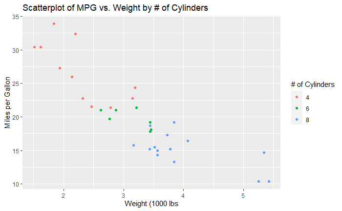

```r
library(ggplot2)

ggplot(mtcars, aes(x = wt, y = mpg, color = as.factor(cyl))) +
  geom_point() +
  labs(title = "Scatterplot of MPG vs. Weight by # of Cylinders",
       x = "Weight (1000 lbs",
       y = "Miles per Gallon",
       color = "# of Cylinders")
```

## #4

I picked the same variables as #3 based on the same hypothesis that heavier vehicles are likely less fuel efficient, which is a practical concern both for consumers and for manufacturers. The pearson coefficient, in general, quantifies the strength and direction of a linear relationship. In this case, we are expecting that weight and mpg are negatively correlated (higher weight is lower mpg). A pearson coefficient of -1 would imply a perfect negative linear relationship. We calculated a value of -0.87 for the correlation of wt and mpg which supports our original hypothesis.

```r
# Generate summary stats
summary(mtcars)
```

```
      mpg             cyl             disp             hp             drat             wt
 Min.   :10.40   Min.   :4.000   Min.   : 71.1   Min.   : 52.0   Min.   :2.760   Min.   :1.513
 1st Qu.:15.43   1st Qu.:4.000   1st Qu.:120.8   1st Qu.: 96.5   1st Qu.:3.080   1st Qu.:2.581
 Median :19.20   Median :6.000   Median :196.3   Median :123.0   Median :3.695   Median :3.325
 Mean   :20.09   Mean   :6.188   Mean   :230.7   Mean   :146.7   Mean   :3.597   Mean   :3.217
 3rd Qu.:22.80   3rd Qu.:8.000   3rd Qu.:326.0   3rd Qu.:180.0   3rd Qu.:3.920   3rd Qu.:3.610
 Max.   :33.90   Max.   :8.000   Max.   :472.0   Max.   :335.0   Max.   :4.930   Max.   :5.424
      qsec             vs               am              gear            carb
 Min.   :14.50   Min.   :0.0000   Min.   :0.0000   Min.   :3.000   Min.   :1.000
 1st Qu.:16.89   1st Qu.:0.0000   1st Qu.:0.0000   1st Qu.:3.000   1st Qu.:2.000
 Median :17.71   Median :0.0000   Median :0.0000   Median :4.000   Median :2.000
 Mean   :17.85   Mean   :0.4375   Mean   :0.4062   Mean   :3.688   Mean   :2.812
 3rd Qu.:18.90   3rd Qu.:1.0000   3rd Qu.:1.0000   3rd Qu.:4.000   3rd Qu.:4.000
 Max.   :22.90   Max.   :1.0000   Max.   :1.0000   Max.   :5.000   Max.   :8.000
```

```r
# Caclulate pearson correlation coefficient on same variables as #3
cor(mtcars$mpg, mtcars$wt, method = "pearson")
```

```
[1] -0.8676594
```

# Part 2

## Question 1

```r
library(ggplot2)
library(tidyverse)
library(XML)

# Adding URL to a variable
file_url <- "http://data.ny.gov/api/views/ngbt-9rwf/rows.xml"

# Downloading file to admissions.xml
download.file(file_url, destfile = "admissions.xml")
# Parsing XML file
xmlfile <- xmlParse("admissions.xml")

# Getting root of XML file
xmltop <- xmlRoot(xmlfile)

# Accessing the first element of the root into a dataframe
admissions_df <- xmlToDataFrame(xmltop[[1]])
View(admissions_df)
```

## Question 2

### Evaluating data

The data has 7 variables which are year, county location, program category, service type, age group, primary substance use, and admissions numbers, with a total of 99,367 observations.

```r
str(admissions_df)
```

```
'data.frame':   99367 obs. of  7 variables:
 $ year                      : chr  "2007" "2007" "2007" "2007" ...
 $ county_of_program_location: chr  "Albany" "Albany" "Albany" "Albany" ...
 $ program_category          : chr  "Crisis" "Crisis" "Crisis" "Crisis" ...
 $ service_type              : chr  "Medical Managed Detoxification" "Medical Managed Detoxification" "Medical Managed Detoxification" "Medical Managed Detoxification" ...
 $ age_group                 : chr  "Under 18" "18 through 24" "18 through 24" "18 through 24" ...
 $ primary_substance_group   : chr  "Heroin" "All Others" "Other Opioids" "Heroin" ...
 $ admissions                : chr  "4" "2" "6" "132" ...
```

### Preparation of data

Some preparation steps that can be performed is to change their data type to their respective types. year and admissions have a chr data type and is changed to numeric data type because they both are number types but were represented as chr type. county_of_program_location, program_category, service_type, age_group have chr type but were changed to factor type because they only have a set number of categories that they can be part of.

```r
# Changing to correct data type
admissions_df <- admissions_df |>
  mutate(year = as.numeric(year),
         county_of_program_location = as.factor(county_of_program_location),
         program_category = as.factor(program_category),
         service_type = as.factor(service_type),
         age_group = as.factor(age_group),
         admissions = as.numeric(admissions)
         )
```

### Summary Statistics

```r
# ADMISSIONS ANALYSIS

admissions_sd <- sd(admissions_df$admissions, na.rm = TRUE)
admissions_mean <- mean(admissions_df$admissions, na.rm = TRUE)
admissions_median <- median(admissions_df$admissions, na.rm = TRUE)
admissions_var <- sqrt(admissions_sd)

# Assign z-scores

admissions_df$admissions_z <- abs((admissions_mean - admissions_df$admissions)/admissions_sd)
admissions_outliers <- admissions_df %>%
  filter(admissions_z > 1.5)
num_outliers <- as.character(length(admissions_outliers))

cat("There are ", num_outliers, " outliers in the data set \nAn outlier is defined as a value having a z-score greater than 1.5 \n\n")
```

[output not shown]

```r
admissions_outliers
```

| year | county_of_program_location | program_category | service_type | age_group | primary_substance_group | admissions | admissions_z |
| --- | --- | --- | --- | --- | --- | --- | --- |
| 2007 | Albany | Crisis | Medical Managed Detoxification | 25 through 34 | Heroin | 276 | 1.905063 |
| 2007 | Albany | Crisis | Medical Managed Detoxification | 35 through 44 | Alcohol | 377 | 2.727032 |
| 2007 | Albany | Crisis | Medical Managed Detoxification | 45 through 54 | Alcohol | 401 | 2.922351 |
| 2007 | Albany | Crisis | Medically Monitored Withdrawal | 35 through 44 | Alcohol | 592 | 4.476766 |
| 2007 | Albany | Crisis | Medically Monitored Withdrawal | 45 through 54 | Alcohol | 661 | 5.038309 |
| 2007 | Albany | Outpatient | Outpatient Clinic | Under 18 | Marijuana | 248 | 1.677191 |
| 2007 | Albany | Outpatient | Outpatient Clinic | 18 through 24 | Marijuana | 284 | 1.970170 |
| 2007 | Albany | Outpatient | Outpatient Clinic | 25 through 34 | Marijuana | 246 | 1.660914 |
| 2007 | Albany | Outpatient | Outpatient Clinic | 25 through 34 | Alcohol | 376 | 2.718893 |
| 2007 | Albany | Outpatient | Outpatient Clinic | 35 through 44 | Alcohol | 357 | 2.564266 |

[output cut: 990 more lines]

### Distribution of Data

To analyze the data I decided to split up the data by 4 categories which are the columns: county_of_program_location age_group program_category primary_substance_group

```r
# COUNTY ANALYSIS

admissions_by_county <- admissions_df %>%
  group_by(county_of_program_location) %>%
  select(county_of_program_location, admissions) %>%
  arrange(county_of_program_location, .locale = "en")

admissions_by_county %>%
  count(county_of_program_location, wt = admissions) %>%
  arrange(county_of_program_location, .locale = "en")
```

| county_of_program_location | n |
| --- | --- |
| Albany | 104558 |
| Allegany | 4770 |
| Bronx | 316706 |
| Broome | 50947 |
| Cattaraugus | 11078 |
| Cayuga | 9289 |
| Chautauqua | 19911 |
| Chemung | 18021 |
| Chenango | 5046 |
| Clinton | 12882 |

[output cut: 51 more lines]

```r
admissions_county_plot <- ggplot(admissions_by_county, aes(x = county_of_program_location, y = admissions)) + geom_bar(stat = "identity") + labs(x = "County", y = "Admissions", title = "Admissions By County") + theme(axis.text.x = element_text(angle = 45, hjust = 1))

# AGE GROUP ANALYSIS

admissions_by_age <- admissions_df %>%
  group_by(age_group) %>%
  select(age_group,admissions) %>%
  arrange(age_group, .locale = "en")

admissions_by_age %>%
  count(age_group) %>%
  arrange(age_group, .locale = "en")
```

| age_group | n |
| --- | --- |
| 18 through 24 | 19909 |
| 25 through 34 | 21479 |
| 35 through 44 | 20045 |
| 45 through 54 | 18188 |
| 55 and Older | 14297 |
| Under 18 | 5449 |

```r
admissions_age_plot <- ggplot(admissions_by_age, aes(x = age_group, y = admissions)) + geom_bar(stat = "identity") + labs(x = "Age Group", y = "Admssions", title = "Admissions By Age Group")


# PROGRAM CATEGORY ANALYSIS

admissions_by_program <- admissions_df %>%
  group_by(program_category) %>%
  select(program_category, admissions) %>%
  arrange(program_category, .locale = "en")

admissions_by_program %>%
  count(program_category, wt = admissions) %>%
  arrange(program_category, .locale = "en")
```

| program_category | n |
| --- | --- |
| Crisis | 1189972 |
| Inpatient | 603784 |
| Opioid Treatment Program | 192931 |
| Outpatient | 1871736 |
| Residential | 298074 |
| Specialized | 8358 |

```r
admissions_program_plot <- ggplot(admissions_by_program, aes(x = program_category, y = admissions)) + geom_bar(stat = "identity") + labs(x = "Program Category", y = "Admissions", title = "Admissions by Program")


# PRIMARY SUBSTANCE ANALYSIS

admissions_by_substance <- admissions_df %>%
  group_by(primary_substance_group) %>%
  select(primary_substance_group,admissions) %>%
  arrange(primary_substance_group, .locale = "en")

admissions_by_substance %>%
  count(primary_substance_group, wt = admissions) %>%
  arrange(primary_substance_group, .locale = "en")
```

| primary_substance_group | n |
| --- | --- |
| Alcohol | 1740673 |
| All Others | 136298 |
| Cocaine | 427996 |
| Heroin | 1027666 |
| Marijuana | 591118 |
| None | 1 |
| Other Opioids | 241103 |

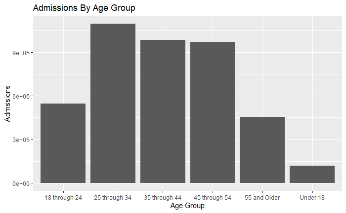

```r
admissions_substance_plot <- ggplot(admissions_by_substance, aes(x = primary_substance_group, y = admissions)) + geom_bar(stat = "identity") + labs(x = "Primary Substance", y = "Admssions", title = "Admissions By Substance")

admissions_age_plot
```

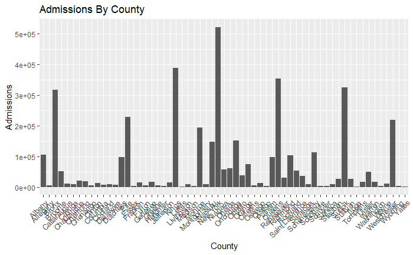

```r
admissions_county_plot
```

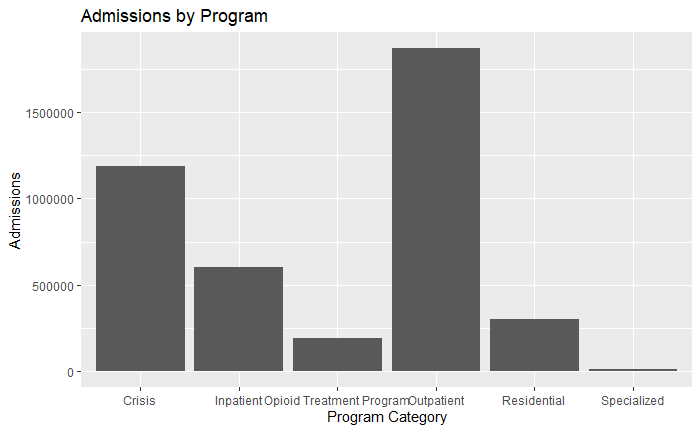

```r
admissions_program_plot
```

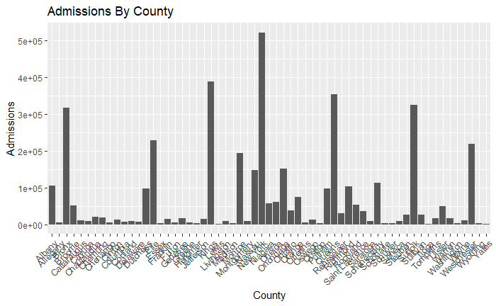

```r
admissions_county_plot
```

## Question 3

### Creating county dataframe

Selecting county_of_program_location and renaming the column to county_name. Keeping distinct rows from the selected column. Adding a column called county_code with respective codes for each county.

```r
county <- admissions_df |>
  select(county_of_program_location) |>
  distinct() |>
  mutate(county_code = c("AL", "AG", "NY", "BM", "CA", "CY", "CH", "CM",
                         "CN", "CL", "CO", "CR", "DE", "DU", "ER", "ES",
                         "FR", "FU", "GE", "GR", "HE", "JE", "NY", "LE",
                         "LI", "MA", "MO", "MG", "NA", "NY", "NI", "ON",
                         "OD", "OT", "OR", "OL", "OS", "OG", "PU", "NY",
                         "RE", "NY", "RO", "SL", "SA", "SC", "SH", "SY",
                         "SE", "ST", "SU", "SV", "TI", "TO", "UL", "WR",
                         "WS", "WA","WE", "WY", "YA")) |>
  relocate(county_code, .before = county_of_program_location)
```

### Creating program_category dataframe

Selecting the program_category column from admissions_df data frame. Removing duplicate values and create a new column called program_code which selects the first two letters from the program_category column to use as program code.

```r
program_category_df <- admissions_df |>
  select(program_category) |>
  distinct()|>
  mutate(program_code = str_extract(program_category, "^[A-Z][a-z]{1}"),
         program_code = toupper(program_code)) |>
  relocate(program_code, .before = program_category)
```

### Creating primary_substance_group dataframe

Selecting primary_substance_group from admission_df data frame. Keeping only distinct values into data frame. Then creating substance_code column with the first letter of each substance as a code.

```r
primary_substance_group_df <- admissions_df |>
  select(primary_substance_group) |>
  distinct() |>
  mutate(substance_code = str_extract(primary_substance_group, "^[A-Z]")) |>
  relocate(substance_code, .before = primary_substance_group)
```

### Creating admission_data dataframe

Utilize mutate function to match values from admissions_data to the values from the smaller dataframes and replace them.

```r
# Create admissions_data df as a copy of admissions_df
admissions_data <- admissions_df

admissions_data <- admissions_data %>%
  select(!admissions_z)

# Replace values in county_of_program_location with county codes from county df
admissions_data <- admissions_data %>%
  mutate(county_of_program_location = ifelse(county_of_program_location %in% county$county_of_program_location, county$county_code[match(county_of_program_location, county$county_of_program_location)], county_of_program_location))

# Replace values in program_category with program codes from program_category_df
admissions_data <- admissions_data %>%
  mutate(program_category = ifelse(program_category %in% program_category_df$program_category, program_category_df$program_code[match(program_category, program_category_df$program_category)], program_category))

# Replace values in primary_substance_group with substance codes from primary_substance_group_df
admissions_data <- admissions_data %>%
  mutate(primary_substance_group = ifelse(primary_substance_group %in% primary_substance_group_df$primary_substance_group, primary_substance_group_df$substance_code[match(primary_substance_group, primary_substance_group_df$primary_substance_group)], primary_substance_group))
```

```r
annualAdmissions <- function() {
  admissions_df |>  # Maybe I'll have to change it to admissions_data ------------------------
    group_by(year) |>
    summarise(admissions_per_year = n()) |>
    ggplot(aes(year, admissions_per_year)) + geom_line() +
    geom_text(x = 2020.5, y = 6900, label = "Max \n(year 2019)", color = "grey40") +
    geom_vline(xintercept = 2019, color = "grey40", linetype = 2) +
    annotate("curve", x = 2020.5, y = 6930, xend = 2019.2, yend = 6960,
             arrow = arrow(length = unit(0.2, "cm"), type = "closed"), color = "grey40") +
    labs(title = "Line chart of admissions per year", x = "Year", y = "Number of Admissions",
         caption = "Visualization of admissions per year")
}
```

## Question 5

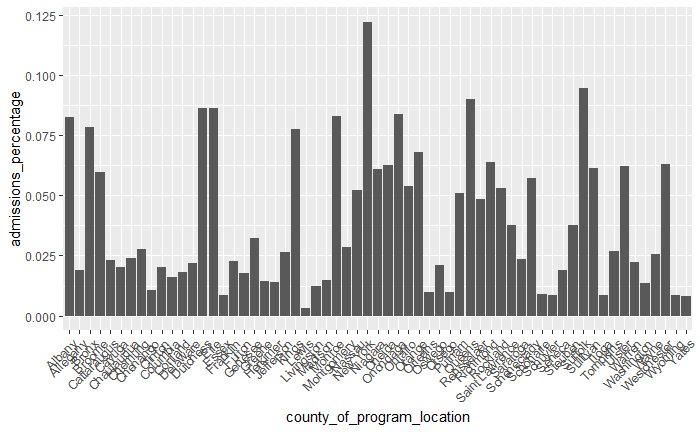

```r
# Getting total number of admissions
total_admissions <- sum(admissions_df$admissions)

admissions_df |>
  group_by(county_of_program_location) |>
  summarise(admissions_per_county = n()) |>
  mutate(admissions_percentage = (admissions_per_county / total_admissions) * 100) |>
  ggplot(aes(county_of_program_location ,admissions_percentage)) + geom_col() +
  theme(axis.text.x = element_text(angle = 45, hjust = 1))
```

```r
NA
```